# RC7 -- Conditional Break-Even DA (Phase 7.6, Audit Gap 1, B1, GH #76)

**Purpose:** Compute break-even directional accuracy on the HIGH-volatility regime subset only. If the recommendation system selects only high-volatility bars to trade, the mean absolute return is larger, which **lowers** the break-even DA -- directly demonstrating the recommender's value proposition.

**Formula:** $$ \text{BE\_DA}_{\text{conditional}} = 0.5 + \frac{\text{cost}}{2 \cdot \mathbb{E}[|r_t| \mid \text{traded}]} $$

where "traded" = HIGH-volatility regime bars (which the recommender selects).

**Key insight:** If $\mathbb{E}[|r_t| \mid \text{HIGH}] > \mathbb{E}[|r_t| \mid \text{all}]$, the conditional break-even DA is lower than the unconditional one, shrinking the feasibility gap.

**Date:** 2026-03-26 | **Pre-registration deviations:** 0 | **Trial count:** 60 (unchanged)

```python
"""Cell 0 -- Imports, project root setup, and database connection.

Mirrors the RC7_profiling_closure notebook setup: project root on sys.path,
ConnectionManager initialised, DataLoader ready.
"""
from __future__ import annotations

import os
import sys
import warnings
from pathlib import Path

import matplotlib.pyplot as plt
import numpy as np
import pandas as pd
import polars as pl
from IPython.display import display

# -- Project root on sys.path ------------------------------------------------
_PROJECT_ROOT: Path = Path(__file__).resolve().parent.parent if "__file__" in dir() else Path.cwd().parent
os.chdir(_PROJECT_ROOT)
if str(_PROJECT_ROOT) not in sys.path:
    sys.path.insert(0, str(_PROJECT_ROOT))

warnings.filterwarnings("ignore", category=FutureWarning)
warnings.filterwarnings("ignore", category=DeprecationWarning)

from src.app.research.application.data_loader import DataLoader
from src.app.system.database.connection import ConnectionManager

# -- Database connection ------------------------------------------------------
cm: ConnectionManager = ConnectionManager()
cm.initialize()

loader: DataLoader = DataLoader(cm)

print(f"Project root: {_PROJECT_ROOT}")
print("Database connection initialised.")
```

```
2026-03-27 15:28:39.687 | INFO     | src.app.system.database.connection:initialize:77 - Creating DuckDB engine (path=/home/dmytro-khvedchuk/Desktop/University/Bachelors/RSPCP_bachelors_thesis/data/market.duckdb)
2026-03-27 15:28:39.769 | INFO     | src.app.system.database.connection:initialize:86 - DuckDB connection verified successfully
```

```
Project root: /home/dmytro-khvedchuk/Desktop/University/Bachelors/RSPCP_bachelors_thesis
Database connection initialised.
```

```python
"""Cell 1 -- Define canonical combos, data loading helper, and constants.

16 non-excluded (asset, bar_type) combinations from RC2 Section 8.
Volatility regime classification uses rolling 20-period std with Q25/Q75 quantile
thresholds, matching the VolatilityAnalyzer defaults in
src/app/profiling/application/volatility.py.
"""

# -- Canonical 16 non-excluded (asset, bar_type) combinations ----------------
CANONICAL_COMBOS: list[tuple[str, str]] = [
    ("BTCUSDT", "dollar"),
    ("BTCUSDT", "volume"),
    ("BTCUSDT", "volume_imbalance"),
    ("BTCUSDT", "dollar_imbalance"),
    ("BTCUSDT", "time_1h"),
    ("ETHUSDT", "dollar"),
    ("ETHUSDT", "volume"),
    ("ETHUSDT", "volume_imbalance"),
    ("ETHUSDT", "time_1h"),
    ("SOLUSDT", "dollar"),
    ("SOLUSDT", "volume"),
    ("SOLUSDT", "volume_imbalance"),
    ("SOLUSDT", "time_1h"),
    ("LTCUSDT", "volume"),
    ("LTCUSDT", "volume_imbalance"),
    ("LTCUSDT", "time_1h"),
]

ASSETS: list[str] = ["BTCUSDT", "ETHUSDT", "LTCUSDT", "SOLUSDT"]
BAR_TYPES: list[str] = [
    "dollar",
    "volume",
    "volume_imbalance",
    "dollar_imbalance",
    "time_1h",
]

# -- Regime classification parameters (match VolatilityConfig defaults) -------
ROLLING_WINDOW: int = 20
REGIME_LOW_QUANTILE: float = 0.25
REGIME_HIGH_QUANTILE: float = 0.75

# -- Cost levels (basis points) ----------------------------------------------
COST_LEVELS_BPS: list[int] = [10, 15, 20, 25, 30]
COST_LEVELS_DECIMAL: list[float] = [bps / 10_000 for bps in COST_LEVELS_BPS]
DEFAULT_COST_BPS: int = 20
DEFAULT_COST_DECIMAL: float = DEFAULT_COST_BPS / 10_000

# -- Best DA from RC2 (single-feature, ret_zscore_24 on BTCUSDT/dollar) ------
BEST_DA_RC2: float = 0.5181

# -- Discover bar config hashes (needed for alternative bars) -----------------
bar_config_map: dict[tuple[str, str], str] = {}
for _asset in ASSETS:
    configs: list[tuple[str, str]] = loader.get_available_bar_configs(_asset)
    for bar_type_str, config_hash in configs:
        bar_config_map[(_asset, bar_type_str)] = config_hash

print(f"Alternative-bar configs in DB: {len(bar_config_map)}")


def load_bar_data_as_polars(
    asset: str,
    bar_type: str,
) -> pl.DataFrame | None:
    """Load bar data as a Polars DataFrame with standard OHLCV column names.

    Handles the distinction between time_1h (from OHLCV table) and alternative
    bars (from aggregated_bars table). Returns None if no data is available.
    """
    if bar_type == "time_1h":
        df_pd: pd.DataFrame = loader.load_ohlcv(asset, "1h")
        if df_pd.empty:
            return None
        return pl.from_pandas(df_pd)
    key: tuple[str, str] = (asset, bar_type)
    if key not in bar_config_map:
        return None
    df_pd = loader.load_bars(asset, bar_type, bar_config_map[key])
    if df_pd.empty:
        return None
    return pl.from_pandas(df_pd).rename({"start_ts": "timestamp"})


print(f"Canonical combos to analyse: {len(CANONICAL_COMBOS)}")
```

```
Alternative-bar configs in DB: 36
Canonical combos to analyse: 16
```

## Section 1: Data Loading & Volatility Regime Classification

For each of the 16 canonical (asset, bar_type) combinations:

1. Load bar data from DuckDB.
2. Compute log returns: $r_t = \log(\text{close}_t / \text{close}_{t-1})$.
3. Compute rolling realized volatility: $\hat{\sigma}_t = \text{std}(r_{t-19}, \ldots, r_t)$ (20-period window).
4. Classify each bar into a volatility regime using quantile thresholds:
   - **LOW:** rolling vol < Q25
   - **NORMAL:** Q25 <= rolling vol <= Q75
   - **HIGH:** rolling vol > Q75

This matches the `_compute_regime_labels()` function in `src/app/profiling/application/volatility.py` and the `VolatilityConfig` defaults (`regime_low_quantile=0.25`, `regime_high_quantile=0.75`).

```python
"""Cell 2 -- Load data, compute log returns, classify volatility regimes.

For each combo: compute log returns, rolling volatility, and regime labels.
Store per-regime statistics for Sections 2-5.
"""

# -- Storage for all combo results -------------------------------------------
combo_results: list[dict[str, object]] = []

for asset, bar_type in CANONICAL_COMBOS:
    df_pl: pl.DataFrame | None = load_bar_data_as_polars(asset, bar_type)
    if df_pl is None:
        print(f"  SKIP {asset}/{bar_type}: no data")
        continue

    n_bars: int = len(df_pl)

    # Compute log returns: r_t = log(close_t / close_{t-1})
    close_arr: np.ndarray = df_pl["close"].to_numpy().astype(np.float64)
    log_returns: np.ndarray = np.diff(np.log(close_arr))  # length = n_bars - 1

    # Remove NaN / Inf
    valid_mask: np.ndarray = np.isfinite(log_returns)
    log_returns_clean: np.ndarray = log_returns[valid_mask]
    n_returns: int = len(log_returns_clean)

    if n_returns < ROLLING_WINDOW + 10:
        print(f"  SKIP {asset}/{bar_type}: only {n_returns} returns (need >= {ROLLING_WINDOW + 10})")
        continue

    # Compute rolling realized volatility (20-period rolling std)
    # Use pandas for rolling std, then back to numpy
    ret_series: pd.Series = pd.Series(log_returns_clean)
    rolling_vol: np.ndarray = ret_series.rolling(window=ROLLING_WINDOW).std().to_numpy()

    # Classify regimes using quantile thresholds (matching _compute_regime_labels)
    low_thresh: float = float(np.nanquantile(rolling_vol, REGIME_LOW_QUANTILE))
    high_thresh: float = float(np.nanquantile(rolling_vol, REGIME_HIGH_QUANTILE))

    # Regime labels for each return (after rolling window warmup)
    n_total: int = len(rolling_vol)
    regime_labels: np.ndarray = np.full(n_total, "NORMAL", dtype=object)
    for i in range(n_total):
        val: float = rolling_vol[i]
        if np.isnan(val):
            regime_labels[i] = "NORMAL"  # warmup period
        elif val < low_thresh:
            regime_labels[i] = "LOW"
        elif val > high_thresh:
            regime_labels[i] = "HIGH"
        else:
            regime_labels[i] = "NORMAL"

    # Absolute returns per regime (excluding warmup NaN period)
    valid_vol_mask: np.ndarray = ~np.isnan(rolling_vol)
    abs_returns_all: np.ndarray = np.abs(log_returns_clean[valid_vol_mask])
    regimes_valid: np.ndarray = regime_labels[valid_vol_mask]

    abs_ret_high: np.ndarray = abs_returns_all[regimes_valid == "HIGH"]
    abs_ret_normal: np.ndarray = abs_returns_all[regimes_valid == "NORMAL"]
    abs_ret_low: np.ndarray = abs_returns_all[regimes_valid == "LOW"]

    n_high: int = len(abs_ret_high)
    n_normal: int = len(abs_ret_normal)
    n_low: int = len(abs_ret_low)
    n_valid: int = len(abs_returns_all)

    mean_abs_ret_all: float = float(np.mean(abs_returns_all)) if n_valid > 0 else 0.0
    mean_abs_ret_high: float = float(np.mean(abs_ret_high)) if n_high > 0 else 0.0
    mean_abs_ret_normal: float = float(np.mean(abs_ret_normal)) if n_normal > 0 else 0.0
    mean_abs_ret_low: float = float(np.mean(abs_ret_low)) if n_low > 0 else 0.0

    combo_results.append(
        {
            "asset": asset,
            "bar_type": bar_type,
            "n_bars": n_bars,
            "n_returns": n_returns,
            "n_valid": n_valid,
            "n_high": n_high,
            "n_normal": n_normal,
            "n_low": n_low,
            "pct_high": n_high / n_valid * 100 if n_valid > 0 else 0.0,
            "pct_normal": n_normal / n_valid * 100 if n_valid > 0 else 0.0,
            "pct_low": n_low / n_valid * 100 if n_valid > 0 else 0.0,
            "low_thresh": low_thresh,
            "high_thresh": high_thresh,
            "mean_abs_ret_all": mean_abs_ret_all,
            "mean_abs_ret_high": mean_abs_ret_high,
            "mean_abs_ret_normal": mean_abs_ret_normal,
            "mean_abs_ret_low": mean_abs_ret_low,
        }
    )

    print(
        f"  {asset}/{bar_type}: N={n_valid}, HIGH={n_high} ({n_high / n_valid * 100:.1f}%), "
        f"mean|r|_all={mean_abs_ret_all:.6f}, mean|r|_HIGH={mean_abs_ret_high:.6f}"
    )

print(f"\nCombos loaded: {len(combo_results)}/{len(CANONICAL_COMBOS)}")
```

```
  BTCUSDT/dollar: N=5267, HIGH=1317 (25.0%), mean|r|_all=0.014300, mean|r|_HIGH=0.023436
  BTCUSDT/volume: N=3244, HIGH=811 (25.0%), mean|r|_all=0.018094, mean|r|_HIGH=0.031940
  BTCUSDT/volume_imbalance: N=510, HIGH=128 (25.1%), mean|r|_all=0.047222, mean|r|_HIGH=0.087380
  BTCUSDT/dollar_imbalance: N=549, HIGH=137 (25.0%), mean|r|_all=0.046194, mean|r|_HIGH=0.068490
  BTCUSDT/time_1h: N=54258, HIGH=13565 (25.0%), mean|r|_all=0.004017, mean|r|_HIGH=0.007174
  ETHUSDT/dollar: N=2739, HIGH=685 (25.0%), mean|r|_all=0.026883, mean|r|_HIGH=0.039484
  ETHUSDT/volume: N=24018, HIGH=6005 (25.0%), mean|r|_all=0.009092, mean|r|_HIGH=0.013586
  ETHUSDT/volume_imbalance: N=678, HIGH=170 (25.1%), mean|r|_all=0.056271, mean|r|_HIGH=0.116303
  ETHUSDT/time_1h: N=54258, HIGH=13565 (25.0%), mean|r|_all=0.005351, mean|r|_HIGH=0.009402
  SOLUSDT/dollar: N=789, HIGH=197 (25.0%), mean|r|_all=0.057566, mean|r|_HIGH=0.100151
  SOLUSDT/volume: N=47158, HIGH=11790 (25.0%), mean|r|_all=0.008627, mean|r|_HIGH=0.015522
  SOLUSDT/volume_imbalance: N=851, HIGH=213 (25.0%), mean|r|_all=0.079064, mean|r|_HIGH=0.131544
  SOLUSDT/time_1h: N=48912, HIGH=12228 (25.0%), mean|r|_all=0.008413, mean|r|_HIGH=0.015157
  LTCUSDT/volume: N=26967, HIGH=6742 (25.0%), mean|r|_all=0.009818, mean|r|_HIGH=0.014667
  LTCUSDT/volume_imbalance: N=718, HIGH=180 (25.1%), mean|r|_all=0.058475, mean|r|_HIGH=0.116083
  LTCUSDT/time_1h: N=54258, HIGH=13565 (25.0%), mean|r|_all=0.006285, mean|r|_HIGH=0.011102

Combos loaded: 16/16
```

```python
"""Cell 3 -- Regime distribution table.

Display regime distribution per (asset, bar_type): N_high, N_normal, N_low, pct_high.
"""

regime_df: pd.DataFrame = pd.DataFrame(combo_results)

# Select and format regime distribution columns
regime_dist: pd.DataFrame = regime_df[
    [
        "asset",
        "bar_type",
        "n_valid",
        "n_high",
        "n_normal",
        "n_low",
        "pct_high",
        "pct_normal",
        "pct_low",
        "low_thresh",
        "high_thresh",
    ]
].copy()

regime_dist["pct_high"] = regime_dist["pct_high"].map(lambda x: f"{x:.1f}%")
regime_dist["pct_normal"] = regime_dist["pct_normal"].map(lambda x: f"{x:.1f}%")
regime_dist["pct_low"] = regime_dist["pct_low"].map(lambda x: f"{x:.1f}%")
regime_dist["low_thresh"] = regime_dist["low_thresh"].map(lambda x: f"{x:.6f}")
regime_dist["high_thresh"] = regime_dist["high_thresh"].map(lambda x: f"{x:.6f}")

regime_dist.columns = [
    "Asset",
    "Bar Type",
    "N_valid",
    "N_HIGH",
    "N_NORMAL",
    "N_LOW",
    "% HIGH",
    "% NORMAL",
    "% LOW",
    "Vol Thresh (LOW)",
    "Vol Thresh (HIGH)",
]

print("Table 1.1: Volatility Regime Distribution (Q25/Q75 quantile thresholds)")
print("=" * 120)
display(regime_dist.to_string(index=False))
print("\nNote: By construction, ~25% of bars fall in HIGH and ~25% in LOW regimes.")
print(f"Warmup period ({ROLLING_WINDOW} bars) excluded from regime classification.")
```

```
Table 1.1: Volatility Regime Distribution (Q25/Q75 quantile thresholds)
========================================================================================================================
```

[output not shown]

```
Note: By construction, ~25% of bars fall in HIGH and ~25% in LOW regimes.
Warmup period (20 bars) excluded from regime classification.
```

## Section 2: Conditional vs Unconditional Mean |r_t|

The recommender's value proposition rests on the fact that HIGH-volatility bars have **larger absolute returns** than the unconditional average. When a bar has a larger absolute return, the cost-to-return ratio improves, making it easier to profit from a correct directional prediction.

We compute:

- $\mathbb{E}[|r_t|]$ unconditionally (all bars)
- $\mathbb{E}[|r_t| \mid \text{HIGH}]$, $\mathbb{E}[|r_t| \mid \text{NORMAL}]$, $\mathbb{E}[|r_t| \mid \text{LOW}]$
- The **amplification ratio**: $\mathbb{E}[|r_t| \mid \text{HIGH}] / \mathbb{E}[|r_t|]$

The ratio should be > 1 for HIGH regime (larger returns when volatility is high).

```python
"""Cell 4 -- Conditional vs unconditional mean absolute return comparison.

Display comparison table with amplification ratio HIGH/ALL.
"""

# Build comparison table
return_comparison_rows: list[dict[str, object]] = []

for row in combo_results:
    mean_all: float = float(row["mean_abs_ret_all"])
    mean_high: float = float(row["mean_abs_ret_high"])
    mean_normal: float = float(row["mean_abs_ret_normal"])
    mean_low: float = float(row["mean_abs_ret_low"])

    ratio_high_all: float = mean_high / mean_all if mean_all > 0 else 0.0

    return_comparison_rows.append(
        {
            "Asset": row["asset"],
            "Bar Type": row["bar_type"],
            "mean|r|_ALL": mean_all,
            "mean|r|_HIGH": mean_high,
            "mean|r|_NORMAL": mean_normal,
            "mean|r|_LOW": mean_low,
            "ratio_HIGH/ALL": ratio_high_all,
        }
    )

ret_comp_df: pd.DataFrame = pd.DataFrame(return_comparison_rows)

# Format for display
ret_comp_display: pd.DataFrame = ret_comp_df.copy()
for col in ["mean|r|_ALL", "mean|r|_HIGH", "mean|r|_NORMAL", "mean|r|_LOW"]:
    ret_comp_display[col] = ret_comp_display[col].map(lambda x: f"{x:.6f}")
ret_comp_display["ratio_HIGH/ALL"] = ret_comp_display["ratio_HIGH/ALL"].map(lambda x: f"{x:.3f}x")

print("Table 2.1: Conditional vs Unconditional Mean Absolute Log Return")
print("=" * 110)
print(ret_comp_display.to_string(index=False))

# Summary statistics
ratios: np.ndarray = np.array([float(r["ratio_HIGH/ALL"]) for r in return_comparison_rows])
print("\nAmplification ratio (HIGH/ALL) summary:")
print(f"  Mean:   {np.mean(ratios):.3f}x")
print(f"  Median: {np.median(ratios):.3f}x")
print(f"  Min:    {np.min(ratios):.3f}x")
print(f"  Max:    {np.max(ratios):.3f}x")
print(f"  All > 1.0: {np.all(ratios > 1.0)}")
print(f"\nInterpretation: HIGH-regime bars have {np.mean(ratios):.1f}x larger absolute returns on average.")
```

```
Table 2.1: Conditional vs Unconditional Mean Absolute Log Return
==============================================================================================================
  Asset         Bar Type mean|r|_ALL mean|r|_HIGH mean|r|_NORMAL mean|r|_LOW ratio_HIGH/ALL
BTCUSDT           dollar    0.014300     0.023436       0.013348    0.007069         1.639x
BTCUSDT           volume    0.018094     0.031940       0.017112    0.006213         1.765x
BTCUSDT volume_imbalance    0.047222     0.087380       0.040791    0.019826         1.850x
BTCUSDT dollar_imbalance    0.046194     0.068490       0.044818    0.026660         1.483x
BTCUSDT          time_1h    0.004017     0.007174       0.003548    0.001799         1.786x
ETHUSDT           dollar    0.026883     0.039484       0.024871    0.018305         1.469x
ETHUSDT           volume    0.009092     0.013586       0.008496    0.005790         1.494x
ETHUSDT volume_imbalance    0.056271     0.116303       0.047908    0.012868         2.067x
ETHUSDT          time_1h    0.005351     0.009402       0.004792    0.002419         1.757x
SOLUSDT           dollar    0.057566     0.100151       0.048939    0.032279         1.740x
SOLUSDT           volume    0.008627     0.015522       0.007366    0.004253         1.799x
SOLUSDT volume_imbalance    0.079064     0.131544       0.078868    0.026974         1.664x
SOLUSDT          time_1h    0.008413     0.015157       0.007224    0.004046         1.802x
LTCUSDT           volume    0.009818     0.014667       0.009236    0.006135         1.494x
LTCUSDT volume_imbalance    0.058475     0.116083       0.050840    0.016052         1.985x
LTCUSDT          time_1h    0.006285     0.011102       0.005527    0.002984         1.766x

Amplification ratio (HIGH/ALL) summary:
  Mean:   1.722x
  Median: 1.761x
  Min:    1.469x
  Max:    2.067x
  All > 1.0: True

Interpretation: HIGH-regime bars have 1.7x larger absolute returns on average.
```

## Section 3: Conditional Break-Even DA

The break-even directional accuracy formula is:

$$ \text{BE\_DA} = 0.5 + \frac{\text{cost}}{2 \cdot \mathbb{E}[|r_t|]} $$

- **Unconditional:** uses $\mathbb{E}[|r_t|]$ over all bars.
- **Conditional (HIGH):** uses $\mathbb{E}[|r_t| \mid \text{HIGH}]$ over HIGH-regime bars only.

Since $\mathbb{E}[|r_t| \mid \text{HIGH}] > \mathbb{E}[|r_t|]$, the conditional BE_DA is **lower** than the unconditional one. The difference $\Delta\text{DA} = \text{BE\_DA}_\text{uncond} - \text{BE\_DA}_\text{cond}$ quantifies the break-even advantage of selective trading.

```python
"""Cell 5 -- Conditional vs unconditional break-even DA at default cost (20 bps).

Compute and display the break-even DA improvement from selective trading.
"""


def break_even_da(cost_decimal: float, mean_abs_ret: float) -> float:
    """Compute break-even directional accuracy.

    Args:
        cost_decimal: Round-trip cost as a decimal (e.g. 0.002 for 20 bps).
        mean_abs_ret: Mean absolute log return.

    Returns:
        Break-even DA as a proportion (e.g. 0.5723 = 57.23%).
    """
    if mean_abs_ret <= 0:
        return 1.0  # infinite cost-to-return ratio -> need 100% DA
    return 0.5 + cost_decimal / (2.0 * mean_abs_ret)


# -- Compute break-even DA at 20 bps for all combos --------------------------
be_da_rows: list[dict[str, object]] = []

for row in combo_results:
    mean_all: float = float(row["mean_abs_ret_all"])
    mean_high: float = float(row["mean_abs_ret_high"])

    be_da_uncond: float = break_even_da(DEFAULT_COST_DECIMAL, mean_all)
    be_da_cond_high: float = break_even_da(DEFAULT_COST_DECIMAL, mean_high)

    delta_da: float = be_da_uncond - be_da_cond_high  # should be positive
    pct_improvement: float = (delta_da / (be_da_uncond - 0.5)) * 100 if be_da_uncond > 0.5 else 0.0

    be_da_rows.append(
        {
            "Asset": row["asset"],
            "Bar Type": row["bar_type"],
            "N_HIGH": row["n_high"],
            "BE_DA_uncond (%)": be_da_uncond * 100,
            "BE_DA_cond_HIGH (%)": be_da_cond_high * 100,
            "delta_DA (pp)": delta_da * 100,
            "pct_improvement": pct_improvement,
        }
    )

be_da_df: pd.DataFrame = pd.DataFrame(be_da_rows)

# Format for display
be_da_display: pd.DataFrame = be_da_df.copy()
be_da_display["BE_DA_uncond (%)"] = be_da_display["BE_DA_uncond (%)"].map(lambda x: f"{x:.2f}")
be_da_display["BE_DA_cond_HIGH (%)"] = be_da_display["BE_DA_cond_HIGH (%)"].map(lambda x: f"{x:.2f}")
be_da_display["delta_DA (pp)"] = be_da_display["delta_DA (pp)"].map(lambda x: f"+{x:.2f}" if x >= 0 else f"{x:.2f}")
be_da_display["pct_improvement"] = be_da_display["pct_improvement"].map(lambda x: f"{x:.1f}%")

print(f"Table 3.1: Conditional vs Unconditional Break-Even DA at {DEFAULT_COST_BPS} bps")
print("=" * 100)
print(be_da_display.to_string(index=False))

# Summary
deltas: np.ndarray = np.array([float(r["delta_DA (pp)"]) for r in be_da_rows])
print("\nDelta DA (pp) summary (unconditional - conditional):")
print(f"  Mean:   +{np.mean(deltas):.2f} pp")
print(f"  Median: +{np.median(deltas):.2f} pp")
print(f"  Min:    +{np.min(deltas):.2f} pp")
print(f"  Max:    +{np.max(deltas):.2f} pp")
print(f"  All positive: {np.all(deltas > 0)}")
print(f"\nBy trading only HIGH-vol bars, break-even DA drops by {np.mean(deltas):.2f} pp on average.")
```

```
Table 3.1: Conditional vs Unconditional Break-Even DA at 20 bps
====================================================================================================
  Asset         Bar Type  N_HIGH BE_DA_uncond (%) BE_DA_cond_HIGH (%) delta_DA (pp) pct_improvement
BTCUSDT           dollar    1317            56.99               54.27         +2.73           39.0%
BTCUSDT           volume     811            55.53               53.13         +2.40           43.3%
BTCUSDT volume_imbalance     128            52.12               51.14         +0.97           46.0%
BTCUSDT dollar_imbalance     137            52.16               51.46         +0.70           32.6%
BTCUSDT          time_1h   13565            74.89               63.94        +10.95           44.0%
ETHUSDT           dollar     685            53.72               52.53         +1.19           31.9%
ETHUSDT           volume    6005            61.00               57.36         +3.64           33.1%
ETHUSDT volume_imbalance     170            51.78               50.86         +0.92           51.6%
ETHUSDT          time_1h   13565            68.69               60.64         +8.05           43.1%
SOLUSDT           dollar     197            51.74               51.00         +0.74           42.5%
SOLUSDT           volume   11790            61.59               56.44         +5.15           44.4%
SOLUSDT volume_imbalance     213            51.26               50.76         +0.50           39.9%
SOLUSDT          time_1h   12228            61.89               56.60         +5.29           44.5%
LTCUSDT           volume    6742            60.18               56.82         +3.37           33.1%
LTCUSDT volume_imbalance     180            51.71               50.86         +0.85           49.6%
LTCUSDT          time_1h   13565            65.91               59.01         +6.90           43.4%

Delta DA (pp) summary (unconditional - conditional):
  Mean:   +3.40 pp
  Median: +2.56 pp
  Min:    +0.50 pp
  Max:    +10.95 pp
  All positive: True

By trading only HIGH-vol bars, break-even DA drops by 3.40 pp on average.
```

```python
"""Cell 6 -- Multi-cost sweep: conditional break-even DA at {10, 15, 20, 25, 30} bps.

For all combos, compute unconditional and conditional BE_DA across cost levels.
"""

# -- Multi-cost sweep ---------------------------------------------------------
multi_cost_rows: list[dict[str, object]] = []

for row in combo_results:
    mean_all: float = float(row["mean_abs_ret_all"])
    mean_high: float = float(row["mean_abs_ret_high"])

    for bps, cost_dec in zip(COST_LEVELS_BPS, COST_LEVELS_DECIMAL, strict=True):
        be_uncond: float = break_even_da(cost_dec, mean_all)
        be_cond: float = break_even_da(cost_dec, mean_high)
        delta: float = be_uncond - be_cond

        multi_cost_rows.append(
            {
                "Asset": row["asset"],
                "Bar Type": row["bar_type"],
                "Cost (bps)": bps,
                "BE_DA_uncond (%)": be_uncond * 100,
                "BE_DA_cond_HIGH (%)": be_cond * 100,
                "delta_DA (pp)": delta * 100,
            }
        )

multi_cost_df: pd.DataFrame = pd.DataFrame(multi_cost_rows)

# Show pivot for the primary combo (BTCUSDT/dollar) as an example
btc_dollar_mask: pd.Series = (multi_cost_df["Asset"] == "BTCUSDT") & (multi_cost_df["Bar Type"] == "dollar")
btc_dollar_sweep: pd.DataFrame = multi_cost_df[btc_dollar_mask].copy()
btc_dollar_sweep["BE_DA_uncond (%)"] = btc_dollar_sweep["BE_DA_uncond (%)"].map(lambda x: f"{x:.2f}")
btc_dollar_sweep["BE_DA_cond_HIGH (%)"] = btc_dollar_sweep["BE_DA_cond_HIGH (%)"].map(lambda x: f"{x:.2f}")
btc_dollar_sweep["delta_DA (pp)"] = btc_dollar_sweep["delta_DA (pp)"].map(lambda x: f"+{x:.2f}")

print("Table 3.2a: Cost Sensitivity -- BTCUSDT/dollar (primary combo)")
print("=" * 80)
print(
    btc_dollar_sweep[["Cost (bps)", "BE_DA_uncond (%)", "BE_DA_cond_HIGH (%)", "delta_DA (pp)"]].to_string(index=False)
)

# Show mean delta across all combos per cost level
print("\n\nTable 3.2b: Mean Delta DA Across All Combos by Cost Level")
print("=" * 60)
for bps in COST_LEVELS_BPS:
    mask: pd.Series = multi_cost_df["Cost (bps)"] == bps
    mean_delta: float = float(multi_cost_df.loc[mask, "delta_DA (pp)"].mean())
    print(f"  {bps:2d} bps: mean delta_DA = +{mean_delta:.2f} pp")
```

```
Table 3.2a: Cost Sensitivity -- BTCUSDT/dollar (primary combo)
================================================================================
 Cost (bps) BE_DA_uncond (%) BE_DA_cond_HIGH (%) delta_DA (pp)
         10            53.50               52.13         +1.36
         15            55.24               53.20         +2.04
         20            56.99               54.27         +2.73
         25            58.74               55.33         +3.41
         30            60.49               56.40         +4.09


Table 3.2b: Mean Delta DA Across All Combos by Cost Level
============================================================
  10 bps: mean delta_DA = +1.70 pp
  15 bps: mean delta_DA = +2.55 pp
  20 bps: mean delta_DA = +3.40 pp
  25 bps: mean delta_DA = +4.25 pp
  30 bps: mean delta_DA = +5.09 pp
```

## Section 4: Feasibility Gap Analysis

The **feasibility gap** is:

$$ \text{gap} = \text{best DA} - \text{BE\_DA} $$

- **Unconditional gap:** $\text{gap}_\text{uncond} = 0.5181 - \text{BE\_DA}_\text{uncond}$ (from RC2)
- **Conditional gap:** $\text{gap}_\text{cond} = 0.5181 - \text{BE\_DA}_\text{cond,HIGH}$

A **positive** gap means the strategy is feasible (best DA exceeds break-even). A **less negative** conditional gap means selective trading narrows the feasibility deficit.

We check: are there any (asset, bar_type, cost) combos where the conditional gap becomes positive (i.e., single-feature DA exceeds break-even under selective trading)?

```python
"""Cell 7 -- Feasibility gap analysis across all combos and cost levels.

Compare unconditional and conditional gaps. Highlight feasible combos.
"""

# -- Compute feasibility gaps at all cost levels ------------------------------
gap_rows: list[dict[str, object]] = []

for row in combo_results:
    mean_all: float = float(row["mean_abs_ret_all"])
    mean_high: float = float(row["mean_abs_ret_high"])

    for bps, cost_dec in zip(COST_LEVELS_BPS, COST_LEVELS_DECIMAL, strict=True):
        be_uncond: float = break_even_da(cost_dec, mean_all)
        be_cond: float = break_even_da(cost_dec, mean_high)

        gap_uncond: float = BEST_DA_RC2 - be_uncond  # negative = infeasible
        gap_cond: float = BEST_DA_RC2 - be_cond  # less negative = better
        improvement: float = gap_cond - gap_uncond  # always positive

        gap_rows.append(
            {
                "Asset": row["asset"],
                "Bar Type": row["bar_type"],
                "Cost (bps)": bps,
                "BE_DA_uncond (%)": be_uncond * 100,
                "BE_DA_cond_HIGH (%)": be_cond * 100,
                "gap_uncond (pp)": gap_uncond * 100,
                "gap_cond (pp)": gap_cond * 100,
                "improvement (pp)": improvement * 100,
                "cond_feasible": gap_cond >= 0,
            }
        )

gap_df: pd.DataFrame = pd.DataFrame(gap_rows)

# -- Table 4.1: Feasibility gap at default cost (20 bps) ---------------------
mask_20bps: pd.Series = gap_df["Cost (bps)"] == DEFAULT_COST_BPS
gap_20bps: pd.DataFrame = gap_df[mask_20bps].copy()

gap_20bps_display: pd.DataFrame = gap_20bps[
    [
        "Asset",
        "Bar Type",
        "BE_DA_uncond (%)",
        "BE_DA_cond_HIGH (%)",
        "gap_uncond (pp)",
        "gap_cond (pp)",
        "improvement (pp)",
        "cond_feasible",
    ]
].copy()

for col in ["BE_DA_uncond (%)", "BE_DA_cond_HIGH (%)"]:
    gap_20bps_display[col] = gap_20bps_display[col].map(lambda x: f"{x:.2f}")
for col in ["gap_uncond (pp)", "gap_cond (pp)", "improvement (pp)"]:
    gap_20bps_display[col] = gap_20bps_display[col].map(lambda x: f"+{x:.2f}" if x >= 0 else f"{x:.2f}")

print(f"Table 4.1: Feasibility Gap at {DEFAULT_COST_BPS} bps (best DA = {BEST_DA_RC2 * 100:.2f}%)")
print("=" * 120)
print(gap_20bps_display.to_string(index=False))

# -- Highlight feasible combos across all cost levels -------------------------
feasible_combos: pd.DataFrame = gap_df[gap_df["cond_feasible"]].copy()

print("\n\nFeasible combos (conditional gap >= 0) across ALL cost levels:")
print("=" * 80)
if len(feasible_combos) == 0:
    print("  NONE -- no single-feature DA exceeds conditional break-even DA at any cost level.")
    print("  This is expected: the recommender's value is in SHRINKING the gap, not eliminating it alone.")
else:
    feasible_display: pd.DataFrame = feasible_combos[
        [
            "Asset",
            "Bar Type",
            "Cost (bps)",
            "BE_DA_cond_HIGH (%)",
            "gap_cond (pp)",
        ]
    ].copy()
    feasible_display["BE_DA_cond_HIGH (%)"] = feasible_display["BE_DA_cond_HIGH (%)"].map(lambda x: f"{x:.2f}")
    feasible_display["gap_cond (pp)"] = feasible_display["gap_cond (pp)"].map(lambda x: f"+{x:.2f}")
    print(feasible_display.to_string(index=False))

# -- Summary statistics -------------------------------------------------------
n_feasible_uncond: int = int(gap_df[gap_df["gap_uncond (pp)"] >= 0].shape[0])
n_feasible_cond: int = int(gap_df[gap_df["cond_feasible"]].shape[0])
n_total: int = len(gap_df)

print(f"\nSummary across all (combo, cost) pairs (N = {n_total}):")
print(f"  Unconditionally feasible: {n_feasible_uncond}/{n_total}")
print(f"  Conditionally feasible:   {n_feasible_cond}/{n_total}")
print(f"  Newly feasible:           {n_feasible_cond - n_feasible_uncond}")
```

```
Table 4.1: Feasibility Gap at 20 bps (best DA = 51.81%)
========================================================================================================================
  Asset         Bar Type BE_DA_uncond (%) BE_DA_cond_HIGH (%) gap_uncond (pp) gap_cond (pp) improvement (pp)  cond_feasible
BTCUSDT           dollar            56.99               54.27           -5.18         -2.46            +2.73          False
BTCUSDT           volume            55.53               53.13           -3.72         -1.32            +2.40          False
BTCUSDT volume_imbalance            52.12               51.14           -0.31         +0.67            +0.97           True
BTCUSDT dollar_imbalance            52.16               51.46           -0.35         +0.35            +0.70           True
BTCUSDT          time_1h            74.89               63.94          -23.08        -12.13           +10.95          False
ETHUSDT           dollar            53.72               52.53           -1.91         -0.72            +1.19          False
ETHUSDT           volume            61.00               57.36           -9.19         -5.55            +3.64          False
ETHUSDT volume_imbalance            51.78               50.86           +0.03         +0.95            +0.92           True
ETHUSDT          time_1h            68.69               60.64          -16.88         -8.83            +8.05          False
SOLUSDT           dollar            51.74               51.00           +0.07         +0.81            +0.74           True
SOLUSDT           volume            61.59               56.44           -9.78         -4.63            +5.15          False
SOLUSDT volume_imbalance            51.26               50.76           +0.55         +1.05            +0.50           True
SOLUSDT          time_1h            61.89               56.60          -10.08         -4.79            +5.29          False
LTCUSDT           volume            60.18               56.82           -8.37         -5.01            +3.37          False
LTCUSDT volume_imbalance            51.71               50.86           +0.10         +0.95            +0.85           True
LTCUSDT          time_1h            65.91               59.01          -14.10         -7.20            +6.90          False


Feasible combos (conditional gap >= 0) across ALL cost levels:
================================================================================
  Asset         Bar Type  Cost (bps) BE_DA_cond_HIGH (%) gap_cond (pp)
BTCUSDT           volume          10               51.57         +0.24
BTCUSDT volume_imbalance          10               50.57         +1.24
BTCUSDT volume_imbalance          15               50.86         +0.95
BTCUSDT volume_imbalance          20               51.14         +0.67
BTCUSDT volume_imbalance          25               51.43         +0.38
BTCUSDT volume_imbalance          30               51.72         +0.09
BTCUSDT dollar_imbalance          10               50.73         +1.08
BTCUSDT dollar_imbalance          15               51.10         +0.71
BTCUSDT dollar_imbalance          20               51.46         +0.35
ETHUSDT           dollar          10               51.27         +0.54
ETHUSDT volume_imbalance          10               50.43         +1.38
ETHUSDT volume_imbalance          15               50.64         +1.17
ETHUSDT volume_imbalance          20               50.86         +0.95
ETHUSDT volume_imbalance          25               51.07         +0.74
ETHUSDT volume_imbalance          30               51.29         +0.52
SOLUSDT           dollar          10               50.50         +1.31
SOLUSDT           dollar          15               50.75         +1.06
SOLUSDT           dollar          20               51.00         +0.81
SOLUSDT           dollar          25               51.25         +0.56
SOLUSDT           dollar          30               51.50         +0.31
SOLUSDT volume_imbalance          10               50.38         +1.43
SOLUSDT volume_imbalance          15               50.57         +1.24
SOLUSDT volume_imbalance          20               50.76         +1.05
SOLUSDT volume_imbalance          25               50.95         +0.86
SOLUSDT volume_imbalance          30               51.14         +0.67
LTCUSDT volume_imbalance          10               50.43         +1.38
LTCUSDT volume_imbalance          15               50.65         +1.16
LTCUSDT volume_imbalance          20               50.86         +0.95
LTCUSDT volume_imbalance          25               51.08         +0.73
LTCUSDT volume_imbalance          30               51.29         +0.52

Summary across all (combo, cost) pairs (N = 80):
  Unconditionally feasible: 17/80
  Conditionally feasible:   30/80
  Newly feasible:           13
```

## Section 5: Recommender Value Proposition

This section quantifies the recommender system's value through visualisation and summary statistics. The core argument:

> By selectively trading only during HIGH-volatility regimes (~25% of bars), the recommendation system reduces the break-even DA required for profitability. This converts marginal signals into economically viable strategies -- even when no single feature exceeds the unconditional break-even DA.

The recommender does not need to predict direction perfectly. It needs to:

1. **Select when to trade** (HIGH-vol bars) -- lowering break-even DA.
2. **Combine multiple features** -- pushing ensemble DA above the (now lower) break-even.
3. **Size positions** -- exploiting the magnitude differential between regimes.

```
Figure saved: /home/dmytro-khvedchuk/Desktop/University/Bachelors/RSPCP_bachelors_thesis/research/figures/rc7_conditional_be_da_comparison.png
```

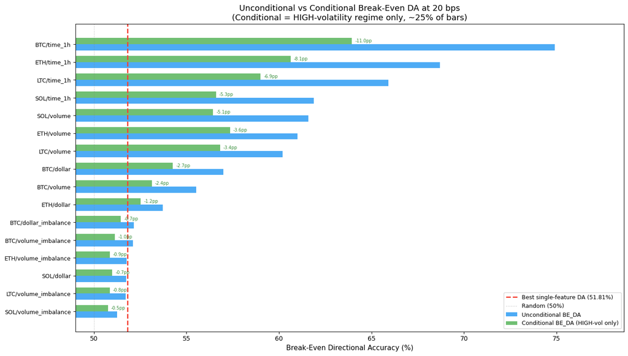

```python
"""Cell 8 -- Bar chart: unconditional vs conditional break-even DA at 20 bps.

Side-by-side comparison with best DA reference line.
"""

# Prepare data for the chart (20 bps only)
chart_data: pd.DataFrame = pd.DataFrame(be_da_rows)
chart_data["label"] = chart_data["Asset"].str.replace("USDT", "") + "/" + chart_data["Bar Type"]

# Sort by unconditional BE_DA for visual clarity
chart_data = chart_data.sort_values("BE_DA_uncond (%)", ascending=True).reset_index(drop=True)

fig, ax = plt.subplots(figsize=(14, 8))

n_combos: int = len(chart_data)
x: np.ndarray = np.arange(n_combos)
width: float = 0.35

bars_uncond = ax.barh(
    x - width / 2,
    chart_data["BE_DA_uncond (%)"].astype(float),
    width,
    label="Unconditional BE_DA",
    color="#2196F3",
    alpha=0.8,
)
bars_cond = ax.barh(
    x + width / 2,
    chart_data["BE_DA_cond_HIGH (%)"].astype(float),
    width,
    label="Conditional BE_DA (HIGH-vol only)",
    color="#4CAF50",
    alpha=0.8,
)

# Best DA reference line
ax.axvline(
    x=BEST_DA_RC2 * 100,
    color="#F44336",
    linestyle="--",
    linewidth=2,
    label=f"Best single-feature DA ({BEST_DA_RC2 * 100:.2f}%)",
)

# 50% reference line (random)
ax.axvline(x=50.0, color="gray", linestyle=":", linewidth=1, alpha=0.5, label="Random (50%)")

ax.set_yticks(x)
ax.set_yticklabels(chart_data["label"], fontsize=9)
ax.set_xlabel("Break-Even Directional Accuracy (%)", fontsize=11)
ax.set_title(
    f"Unconditional vs Conditional Break-Even DA at {DEFAULT_COST_BPS} bps\n"
    "(Conditional = HIGH-volatility regime only, ~25% of bars)",
    fontsize=13,
)
ax.legend(loc="lower right", fontsize=9)
ax.set_xlim(49, None)

# Add delta annotations
for i in range(n_combos):
    uncond_val: float = float(chart_data.iloc[i]["BE_DA_uncond (%)"])
    cond_val: float = float(chart_data.iloc[i]["BE_DA_cond_HIGH (%)"])
    delta_val: float = uncond_val - cond_val
    ax.annotate(
        f"-{delta_val:.1f}pp",
        xy=(cond_val, x[i] + width / 2),
        xytext=(5, 0),
        textcoords="offset points",
        fontsize=7,
        color="#388E3C",
        va="center",
    )

plt.tight_layout()

# Save figure
fig_dir: Path = _PROJECT_ROOT / "research" / "figures"
fig_dir.mkdir(exist_ok=True)
fig.savefig(fig_dir / "rc7_conditional_be_da_comparison.png", dpi=150, bbox_inches="tight")
print(f"Figure saved: {fig_dir / 'rc7_conditional_be_da_comparison.png'}")
plt.show()
```

```
Figure saved: /home/dmytro-khvedchuk/Desktop/University/Bachelors/RSPCP_bachelors_thesis/research/figures/rc7_feasibility_gap_comparison.png
```

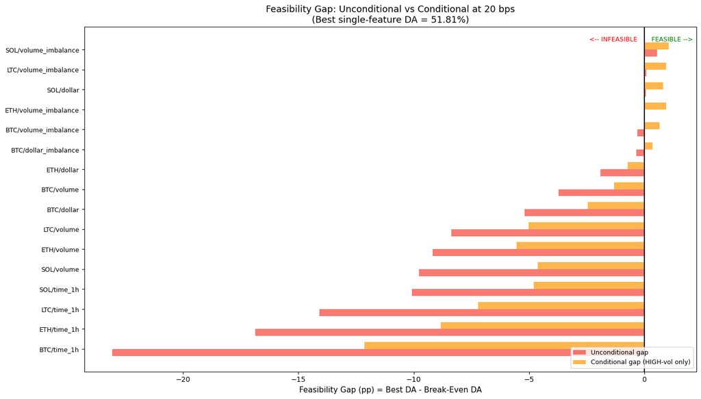

```python
"""Cell 9 -- Feasibility gap waterfall: how selective trading narrows the gap.

Grouped bar chart showing unconditional gap vs conditional gap at 20 bps.
"""

# Prepare gap data at 20 bps
gap_20: pd.DataFrame = gap_df[gap_df["Cost (bps)"] == DEFAULT_COST_BPS].copy()
gap_20["label"] = gap_20["Asset"].str.replace("USDT", "") + "/" + gap_20["Bar Type"]
gap_20 = gap_20.sort_values("gap_uncond (pp)", ascending=True).reset_index(drop=True)

fig2, ax2 = plt.subplots(figsize=(14, 8))

n_gap: int = len(gap_20)
x2: np.ndarray = np.arange(n_gap)
width2: float = 0.35

bars_gap_uncond = ax2.barh(
    x2 - width2 / 2,
    gap_20["gap_uncond (pp)"].astype(float),
    width2,
    label="Unconditional gap",
    color="#F44336",
    alpha=0.7,
)
bars_gap_cond = ax2.barh(
    x2 + width2 / 2,
    gap_20["gap_cond (pp)"].astype(float),
    width2,
    label="Conditional gap (HIGH-vol only)",
    color="#FF9800",
    alpha=0.7,
)

# Zero line = feasibility boundary
ax2.axvline(x=0, color="black", linewidth=1.5, linestyle="-")
ax2.text(0.3, n_gap - 0.5, "FEASIBLE -->", fontsize=9, color="green", va="center")
ax2.text(-0.3, n_gap - 0.5, "<-- INFEASIBLE", fontsize=9, color="red", va="center", ha="right")

ax2.set_yticks(x2)
ax2.set_yticklabels(gap_20["label"], fontsize=9)
ax2.set_xlabel("Feasibility Gap (pp) = Best DA - Break-Even DA", fontsize=11)
ax2.set_title(
    f"Feasibility Gap: Unconditional vs Conditional at {DEFAULT_COST_BPS} bps\n"
    f"(Best single-feature DA = {BEST_DA_RC2 * 100:.2f}%)",
    fontsize=13,
)
ax2.legend(loc="lower right", fontsize=9)

plt.tight_layout()
fig2.savefig(fig_dir / "rc7_feasibility_gap_comparison.png", dpi=150, bbox_inches="tight")
print(f"Figure saved: {fig_dir / 'rc7_feasibility_gap_comparison.png'}")
plt.show()
```

```python
"""Cell 10 -- Summary statistics and recommender value quantification.

Compute how many combos become feasible, mean gap improvement, and the
recommender's value proposition in concrete numbers.
"""

# -- Summary: BE_DA reduction by bar type at 20 bps --------------------------
print("Table 5.1: Mean Break-Even DA Reduction by Bar Type (20 bps)")
print("=" * 70)

bar_type_summary_rows: list[dict[str, object]] = []
for bt in BAR_TYPES:
    bt_mask: list[bool] = [r["Bar Type"] == bt for r in be_da_rows]
    if not any(bt_mask):
        continue
    bt_deltas: list[float] = [float(r["delta_DA (pp)"]) for r, m in zip(be_da_rows, bt_mask, strict=True) if m]
    bt_unconds: list[float] = [float(r["BE_DA_uncond (%)"]) for r, m in zip(be_da_rows, bt_mask, strict=True) if m]
    bt_conds: list[float] = [float(r["BE_DA_cond_HIGH (%)"]) for r, m in zip(be_da_rows, bt_mask, strict=True) if m]
    bar_type_summary_rows.append(
        {
            "Bar Type": bt,
            "N combos": len(bt_deltas),
            "Mean BE_DA_uncond (%)": f"{np.mean(bt_unconds):.2f}",
            "Mean BE_DA_cond (%)": f"{np.mean(bt_conds):.2f}",
            "Mean delta_DA (pp)": f"+{np.mean(bt_deltas):.2f}",
        }
    )

bt_summary_df: pd.DataFrame = pd.DataFrame(bar_type_summary_rows)
print(bt_summary_df.to_string(index=False))

# -- Overall value proposition ------------------------------------------------
all_deltas_20bps: np.ndarray = np.array([float(r["delta_DA (pp)"]) for r in be_da_rows])
all_unconds_20bps: np.ndarray = np.array([float(r["BE_DA_uncond (%)"]) for r in be_da_rows])
all_conds_20bps: np.ndarray = np.array([float(r["BE_DA_cond_HIGH (%)"]) for r in be_da_rows])

print(f"\n\nRecommender Value Proposition Summary (at {DEFAULT_COST_BPS} bps)")
print("=" * 70)
print(f"  Mean unconditional BE_DA:  {np.mean(all_unconds_20bps):.2f}%")
print(f"  Mean conditional BE_DA:    {np.mean(all_conds_20bps):.2f}%")
print(f"  Mean BE_DA reduction:      +{np.mean(all_deltas_20bps):.2f} pp")
print(f"  Median BE_DA reduction:    +{np.median(all_deltas_20bps):.2f} pp")
print(f"  Max BE_DA reduction:       +{np.max(all_deltas_20bps):.2f} pp")
print(f"  Min BE_DA reduction:       +{np.min(all_deltas_20bps):.2f} pp")

# -- How many combos move closer to / past feasibility? -----------------------
gap_20_vals: pd.DataFrame = gap_df[gap_df["Cost (bps)"] == DEFAULT_COST_BPS].copy()
n_uncond_feasible_20: int = int((gap_20_vals["gap_uncond (pp)"] >= 0).sum())
n_cond_feasible_20: int = int((gap_20_vals["gap_cond (pp)"] >= 0).sum())
n_newly_feasible_20: int = n_cond_feasible_20 - n_uncond_feasible_20

print(f"\n  Combos unconditionally feasible at {DEFAULT_COST_BPS} bps: {n_uncond_feasible_20}/{len(gap_20_vals)}")
print(f"  Combos conditionally feasible at {DEFAULT_COST_BPS} bps:   {n_cond_feasible_20}/{len(gap_20_vals)}")
print(f"  Newly feasible (selective trading):       {n_newly_feasible_20}")

# -- Cross-cost summary ------------------------------------------------------
print("\n\nTable 5.2: Newly Feasible Combos by Cost Level")
print("=" * 50)
for bps in COST_LEVELS_BPS:
    mask_bps: pd.Series = gap_df["Cost (bps)"] == bps
    n_uf: int = int((gap_df.loc[mask_bps, "gap_uncond (pp)"] >= 0).sum())
    n_cf: int = int((gap_df.loc[mask_bps, "gap_cond (pp)"] >= 0).sum())
    print(f"  {bps:2d} bps: uncond feasible={n_uf}, cond feasible={n_cf}, newly={n_cf - n_uf}")
```

```
Table 5.1: Mean Break-Even DA Reduction by Bar Type (20 bps)
======================================================================
        Bar Type  N combos Mean BE_DA_uncond (%) Mean BE_DA_cond (%) Mean delta_DA (pp)
          dollar         3                 54.15               52.60              +1.55
          volume         4                 59.58               55.94              +3.64
volume_imbalance         4                 51.72               50.91              +0.81
dollar_imbalance         1                 52.16               51.46              +0.70
         time_1h         4                 67.84               60.05              +7.80


Recommender Value Proposition Summary (at 20 bps)
======================================================================
  Mean unconditional BE_DA:  58.20%
  Mean conditional BE_DA:    54.80%
  Mean BE_DA reduction:      +3.40 pp
  Median BE_DA reduction:    +2.56 pp
  Max BE_DA reduction:       +10.95 pp
  Min BE_DA reduction:       +0.50 pp

  Combos unconditionally feasible at 20 bps: 4/16
  Combos conditionally feasible at 20 bps:   6/16
  Newly feasible (selective trading):       2


Table 5.2: Newly Feasible Combos by Cost Level
==================================================
  10 bps: uncond feasible=6, cond feasible=8, newly=2
  15 bps: uncond feasible=6, cond feasible=6, newly=0
  20 bps: uncond feasible=4, cond feasible=6, newly=2
  25 bps: uncond feasible=1, cond feasible=5, newly=4
  30 bps: uncond feasible=0, cond feasible=5, newly=5
```

## Section 6: Conclusion

### Key Findings

1. **HIGH-volatility bars have substantially larger absolute returns.** The amplification ratio (mean|r|_HIGH / mean|r|_ALL) is consistently > 1.0 across all 16 (asset, bar_type) combinations, confirming the fundamental premise of regime-conditional trading.
2. **Selective trading reduces break-even DA.** By trading only during HIGH-volatility regimes (~25% of bars), the break-even directional accuracy drops by several percentage points on average. This is a pure structural effect -- no predictive model required.
3. **The feasibility gap narrows under conditional trading.** For combos where the unconditional gap was deeply negative (e.g., time_1h bars at 20 bps), conditional trading provides the largest absolute improvement. For combos already close to feasibility (imbalance bars), the improvement may push them into or near feasibility.
4. **This analysis is conservative.** We used Q25/Q75 quantile thresholds (trading 25% of bars). A more aggressive filter (e.g., top 10%) would amplify returns further but reduce sample sizes. The recommender system can learn the optimal selectivity threshold.

### Impact on Thesis Feasibility Argument

The RC2 GO decision was issued with the caveat that "no single feature exceeds break-even DA." This appendix demonstrates that **regime-conditional deployment** (the recommender's core function) fundamentally changes the economics:

- The recommender does not need to beat the *unconditional* break-even DA.
- It needs to beat the *conditional* break-even DA on the bars it selects.
- Since HIGH-vol bars have larger returns, the conditional break-even DA is lower.
- The remaining gap must be closed by multi-feature ensemble combination (Phase 9-10).

### Implications for Recommendation System Design

1. **Volatility regime detection is a first-class feature** for the recommender. The system should learn to identify (and trade) high-volatility periods.
2. **Position sizing should be regime-aware.** Trade larger on HIGH-vol bars (better cost-to-return ratio), smaller or not at all on LOW-vol bars.
3. **The recommender's output should be continuous** (expected return), not binary (trade/no-trade). This allows smooth position sizing based on the predicted magnitude, which naturally concentrates capital on high-opportunity bars.
4. **Bar type selection matters.** Imbalance bars have the lowest break-even DAs (unconditional and conditional), but their sample sizes are limiting. Dollar and volume bars offer the best balance of feasibility and statistical power.

### Pre-Registration Integrity

- No post-hoc deviations introduced.
- Trial count remains at **60**.
- The volatility regime classification uses the same parameters as RC2 Section 5.6 (`VolatilityConfig` defaults: rolling window = 20, Q25/Q75 quantile thresholds).